# data-inventory

Britta Schumacher

February 8, 2021

Farm Demographics Highlights (2014): https://www.nass.usda.gov/Publications/Highlights/2014/Farm_Demographics/Highlights_Farm_Demographics.pdf

What follows is an inventory of data availability through time and across space for various demographic variables from the COA (these are both variables we have previously cleaned and tidied and NEW variables that I've sought out since reading Horst & Marion). This .RDS only has data for 2002, 2007, 2012, and 2017, so I'll have to scrape for individual .csv's from QuickStats for 1997!

### Let's just explore this thing a bit, again... I'm pretty rusty on the weird, nested, COA-structure.

```r
library(tidyverse)
library(viridis)
cty <- readRDS("./data/county.RDS")
coa <- readRDS("./data/NASS_census.RDS")
# okay so there are 4 SECTOR_DESC options, one is "DEMOGRAPHICS"; let's filter for that and see what options we have
d <- coa %>% filter(SECTOR_DESC == "DEMOGRAPHICS")

# there are a whole bunch of options within GROUP_DESC, but first I am going to look at "OPERATORS" & "PRODUCERS"
do <- d %>% filter(GROUP_DESC == "OPERATORS" | GROUP_DESC == "PRODUCERS")

# let's just look into Black/African American and see what we got
dor <- do %>%  filter(DOMAIN_DESC == "TOTAL") %>% filter(COUNTY_NAME == "BERKS") %>% select(GEOID, YEAR, COMMODITY_DESC, STATISTICCAT_DESC, UNIT_DESC, SHORT_DESC, VALUE)

# we have options for operators, operations, and acres operated... could be interesting... (& we'll have this for all demographic categories)
# There are so many different ways to slice this data... I'm having a hard time making decisions about the "how".
```

## Who are our (US) farmers? (see https://usafacts.org/articles/farmer-demographics/) and how have they shifted in the 21st century thus far?

# Sex

```r
s <- do %>% filter(CLASS_DESC == "MALE" | CLASS_DESC == "FEMALE") %>% filter(DOMAIN_DESC == "TOTAL") %>% filter(AGG_LEVEL_DESC == "COUNTY") %>%  select(GEOID, YEAR, CLASS_DESC, COMMODITY_DESC, STATISTICCAT_DESC, UNIT_DESC, SHORT_DESC, VALUE) %>% filter(SHORT_DESC != "OPERATORS, PRINCIPAL, FEMALE - AREA OPERATED, MEASURED IN ACRES / OPERATION")

# total available
data_avail <- s %>%
  group_by(YEAR, SHORT_DESC) %>%
  summarise(count_NA = sum(is.na(VALUE)),
            n = sum(length(VALUE))) %>%
  mutate(perc = 1 - (count_NA/n)) %>% # availability determined by NA/n
  mutate(cty_rep = (n/3130)) %>% # percent of cty's represented in data
  mutate(t_m = (3130-n) + count_NA) %>% # total number of missing data points (including NA and non-existent data)
  mutate(t = 1 - (t_m/3130))
data_avail
```

```
## # A tibble: 42 x 8
## # Groups:   YEAR [4]
##     YEAR SHORT_DESC                     count_NA     n  perc cty_rep   t_m     t
##    <int> <fct>                             <int> <int> <dbl>   <dbl> <dbl> <dbl>
##  1  2002 OPERATORS, FEMALE - ACRES OPE~       26  3071 0.992   0.981    85 0.973
##  2  2002 OPERATORS, FEMALE - NUMBER OF~        0  3071 1       0.981    59 0.981
##  3  2002 OPERATORS, FEMALE - NUMBER OF~        0  3071 1       0.981    59 0.981
##  4  2002 OPERATORS, PRINCIPAL, FEMALE ~       89  3061 0.971   0.978   158 0.950
##  5  2002 OPERATORS, PRINCIPAL, FEMALE ~        0  3061 1       0.978    69 0.978
##  6  2002 OPERATORS, PRINCIPAL, MALE - ~       95  3076 0.969   0.983   149 0.952
##  7  2002 OPERATORS, PRINCIPAL, MALE - ~        1  3076 1.00    0.983    55 0.982
##  8  2007 OPERATORS, FEMALE - ACRES OPE~       26  3074 0.992   0.982    82 0.974
##  9  2007 OPERATORS, FEMALE - NUMBER OF~        0  3074 1       0.982    56 0.982
## 10  2007 OPERATORS, FEMALE - NUMBER OF~        2  3074 0.999   0.982    58 0.981
## # ... with 32 more rows
```

```r
levels(s$STATISTICCAT_DESC)[levels(s$STATISTICCAT_DESC)=="PRODUCERS"] <- "OPERATORS"
levels(s$COMMODITY_DESC)[levels(s$COMMODITY_DESC)=="PRODUCERS"] <- "OPERATORS"
levels(s$COMMODITY_DESC)[levels(s$COMMODITY_DESC)=="PRODUCERS, PRINCIPAL"] <- "OPERATORS, PRINCIPAL"

# we've actually got some pretty decent data availability, here.
sw <- s %>% select(GEOID, YEAR, CLASS_DESC, COMMODITY_DESC, STATISTICCAT_DESC, VALUE) %>% filter(STATISTICCAT_DESC == "OPERATORS" | STATISTICCAT_DESC == "OPERATIONS" | STATISTICCAT_DESC == "AREA OPERATED") %>% filter(COMMODITY_DESC == "OPERATORS")

st <- sw %>% pivot_wider(names_from = STATISTICCAT_DESC, values_from = VALUE)

colnames(st) <- c("GEOID", "YEAR", "SEX", "TYPE", "AREA_OPERATED", "OPERATIONS", "OPERATORS")

sb <- s %>% select(GEOID, YEAR, CLASS_DESC, COMMODITY_DESC, STATISTICCAT_DESC, VALUE) %>% filter(STATISTICCAT_DESC == "OPERATIONS" | STATISTICCAT_DESC == "AREA OPERATED") %>% filter(COMMODITY_DESC == "OPERATORS, PRINCIPAL")

ss <- sb %>% pivot_wider(names_from = STATISTICCAT_DESC, values_from = VALUE)

colnames(ss) <- c("GEOID", "YEAR", "SEX", "TYPE", "AREA_OPERATED", "OPERATIONS")
ss[,"OPERATORS"] <- NA

sex <- rbind(st, ss)
```

### Now let's visualize!

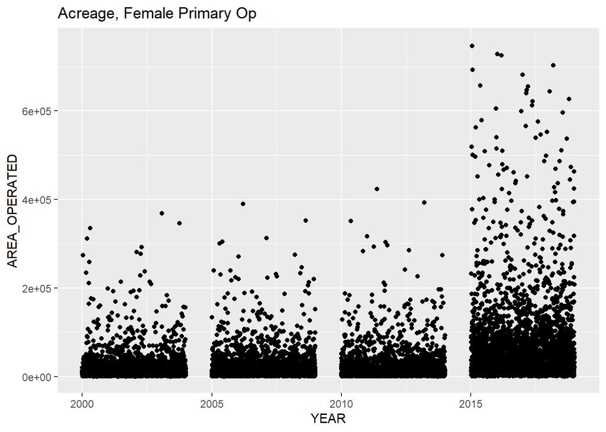

```r
# Women operators and primary operators
fp <- sex %>% filter(SEX == "FEMALE") %>% filter(TYPE == "OPERATORS, PRINCIPAL")
ggplot(fp, aes(YEAR, AREA_OPERATED)) + geom_jitter() + ylim(0,750000) + ggtitle("Acreage, Female Primary Op")
```

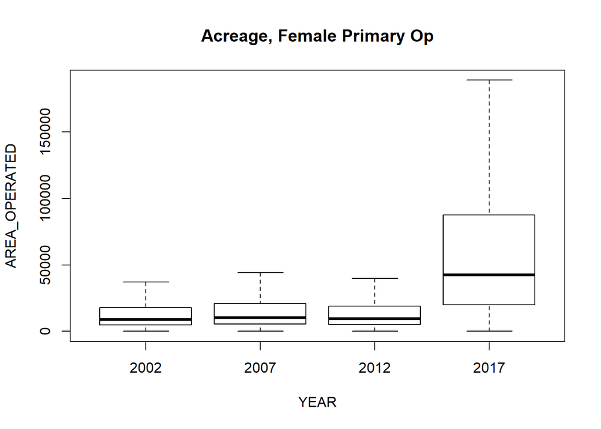

```r
boxplot(AREA_OPERATED ~ YEAR, data = fp, main = "Acreage, Female Primary Op", outline=FALSE)
```

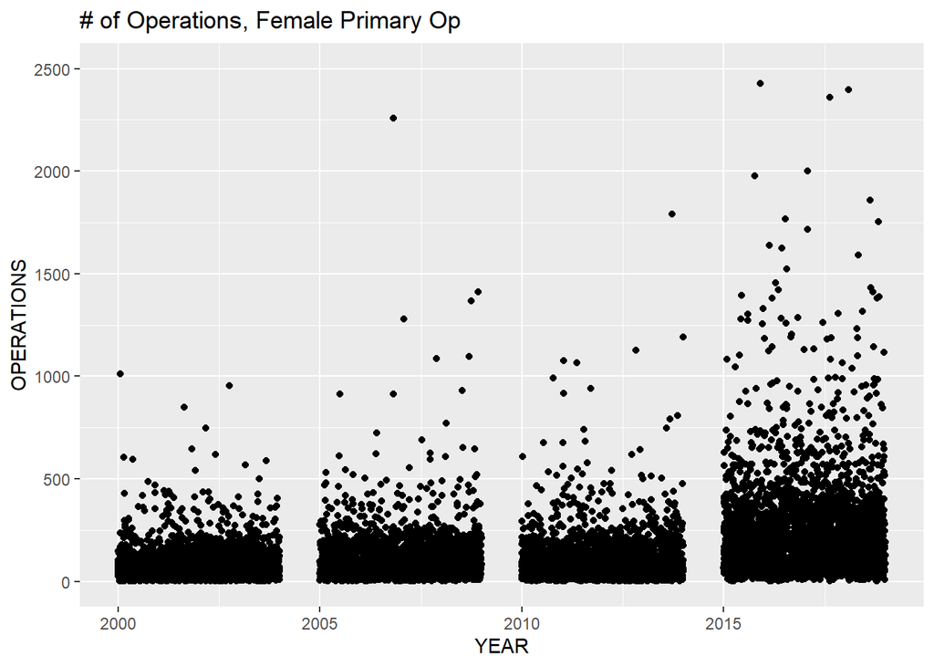

```r
ggplot(fp, aes(YEAR, OPERATIONS)) + geom_jitter() + ylim(0,2500) + ggtitle("# of Operations, Female Primary Op")
```

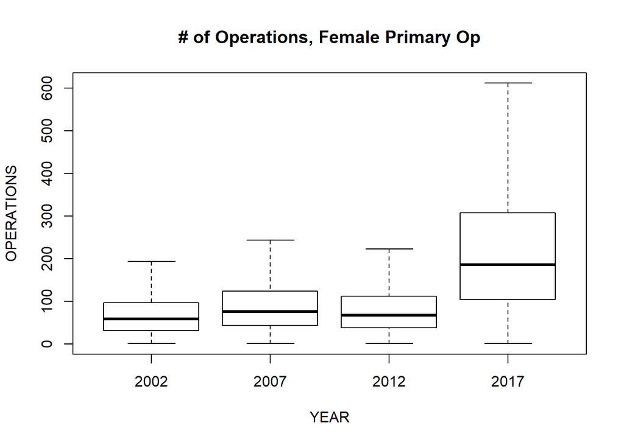

```r
boxplot(OPERATIONS ~ YEAR, data = fp, main = "# of Operations, Female Primary Op", outline=FALSE)
```

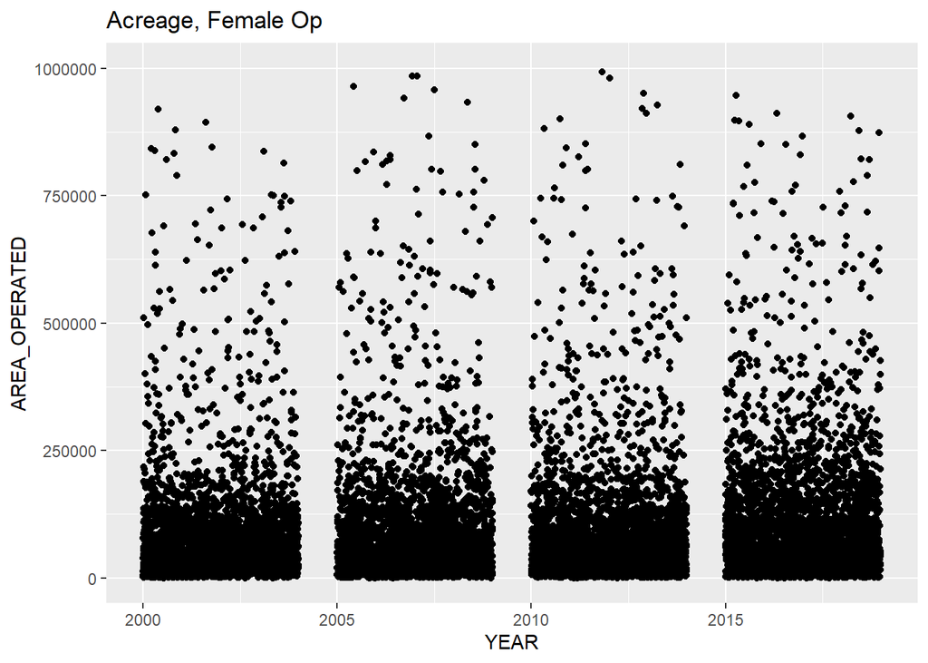

```r
f <- sex %>% filter(SEX == "FEMALE") %>% filter(TYPE == "OPERATORS")
ggplot(f, aes(YEAR, AREA_OPERATED)) + geom_jitter() + ylim(0,1000000) + ggtitle("Acreage, Female Op")
```

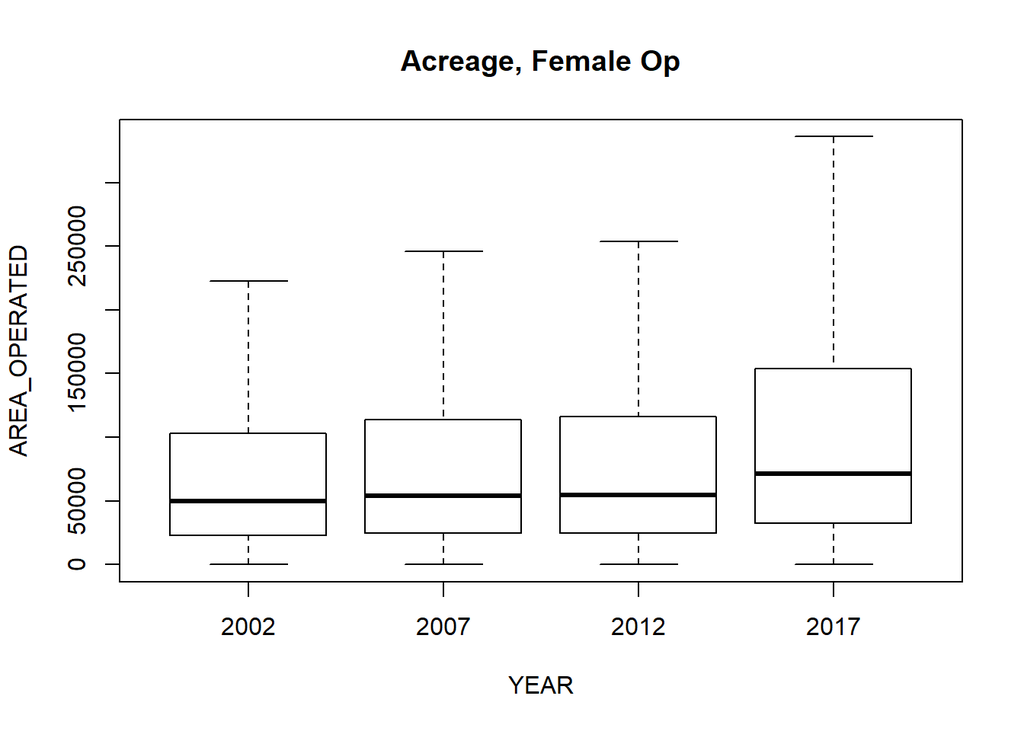

```r
boxplot(AREA_OPERATED ~ YEAR, data = f, main = "Acreage, Female Op", outline=FALSE)
```

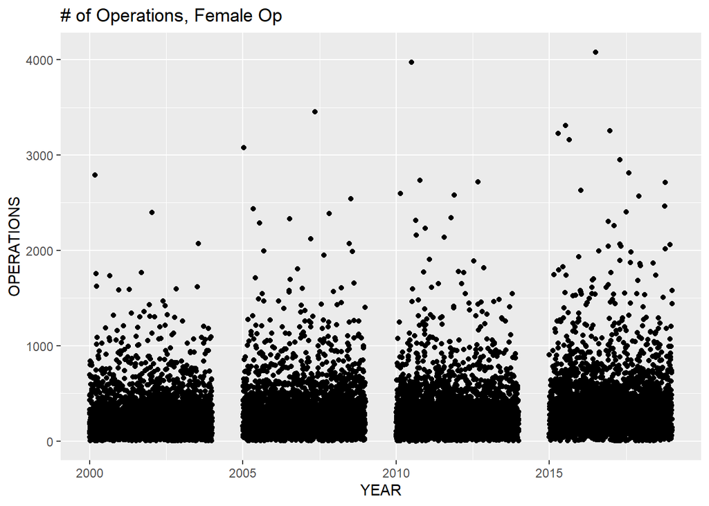

```r
ggplot(f, aes(YEAR, OPERATIONS)) + geom_jitter()  + ggtitle("# of Operations, Female Op")
```

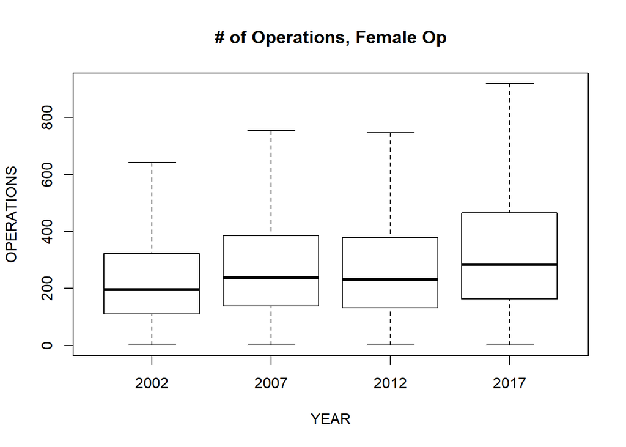

```r
boxplot(OPERATIONS ~ YEAR, data = f, main = "# of Operations, Female Op", outline=FALSE)
```

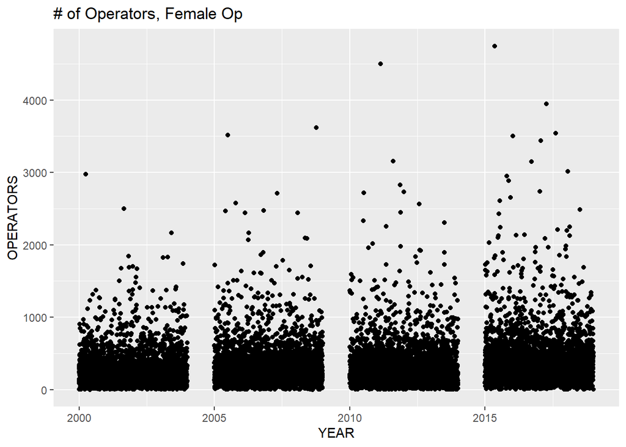

```r
ggplot(f, aes(YEAR, OPERATORS)) + geom_jitter()  + ggtitle("# of Operators, Female Op")
```

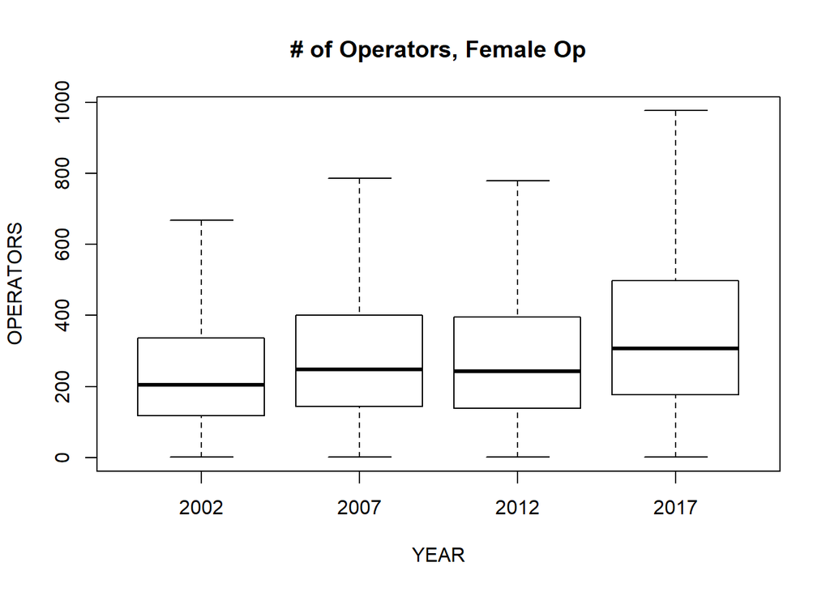

```r
boxplot(OPERATORS ~ YEAR, data = f, main = "# of Operators, Female Op", outline=FALSE)
```

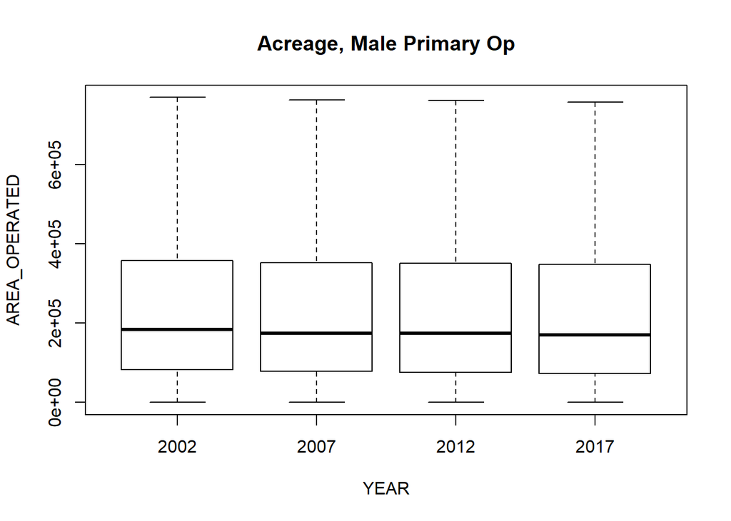

```r
# Male operators and primary operators
mp <- sex %>% filter(SEX == "MALE") %>% filter(TYPE == "OPERATORS, PRINCIPAL")
boxplot(AREA_OPERATED ~ YEAR, data = mp, main = "Acreage, Male Primary Op", outline=FALSE)
```

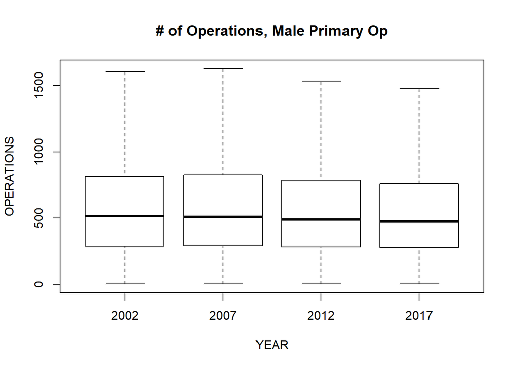

```r
boxplot(OPERATIONS ~ YEAR, data = mp, main = "# of Operations, Male Primary Op", outline=FALSE)
```

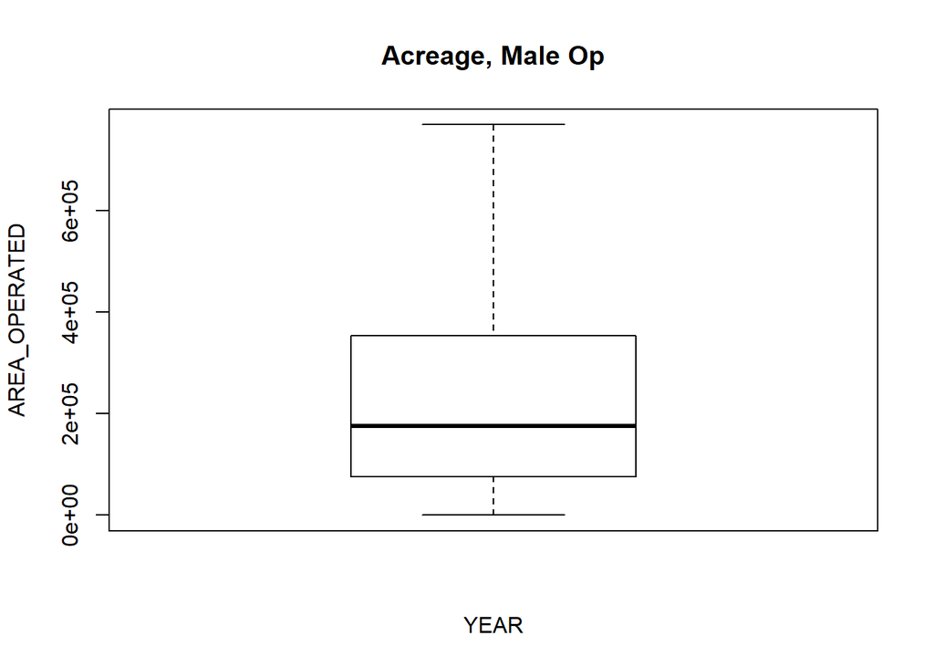

```r
m <- sex %>% filter(SEX == "MALE") %>% filter(TYPE == "OPERATORS")
boxplot(AREA_OPERATED ~ YEAR, data = m, main = "Acreage, Male Op", outline=FALSE) # only 2017
```

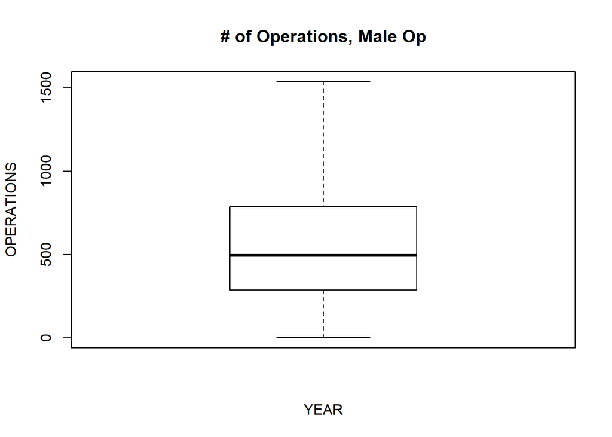

```r
boxplot(OPERATIONS ~ YEAR, data = m, main = "# of Operations, Male Op", outline=FALSE) # only 2017
```

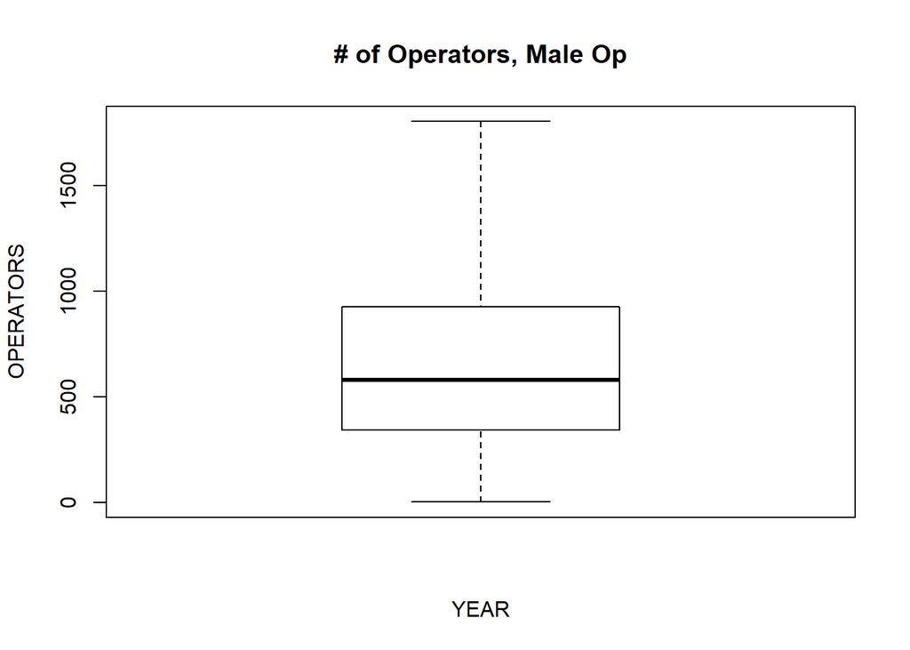

```r
boxplot(OPERATORS ~ YEAR, data = m, main = "# of Operators, Male Op", outline=FALSE) # only 2017
```

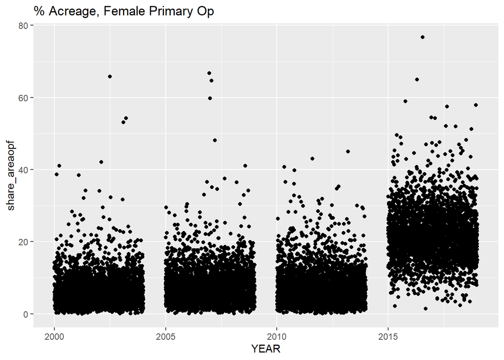

```r
# Percent female
m <- sex %>% filter(SEX == "MALE")
f <- sex %>% filter(SEX == "FEMALE")

share <- merge(m,f, by = c("GEOID", "YEAR", "TYPE"))

percf <- share %>% mutate(share_areaopf = AREA_OPERATED.y / (AREA_OPERATED.x + AREA_OPERATED.y)*100,
                          share_opf = OPERATIONS.y / (OPERATIONS.x + OPERATIONS.y)*100,
                          share_optrsf = OPERATORS.y / (OPERATORS.x + OPERATORS.y)*100) %>%
  select(GEOID, YEAR, TYPE, share_areaopf, share_opf, share_optrsf)

percf_p <- percf %>% filter(TYPE == "OPERATORS, PRINCIPAL")
percf_o <- percf %>% filter(TYPE == "OPERATORS")
# jitterplot/boxplot
# primary operators
ggplot(percf_p, aes(YEAR, share_areaopf)) + geom_jitter() + ggtitle("% Acreage, Female Primary Op")
```

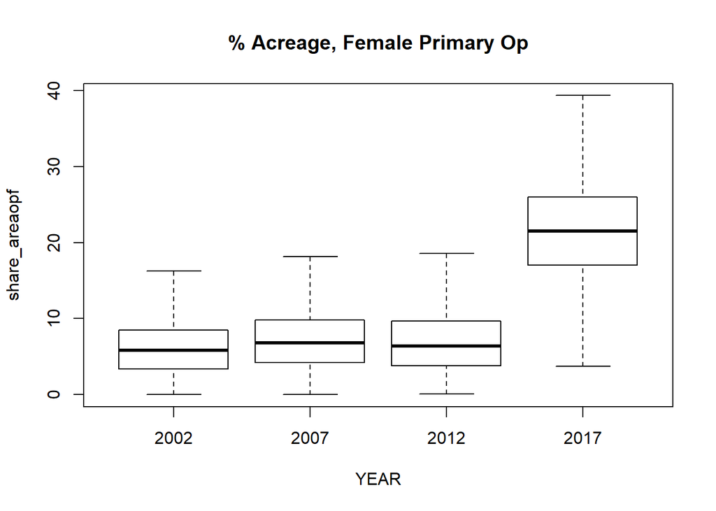

```r
boxplot(share_areaopf ~ YEAR, data = percf_p, main = "% Acreage, Female Primary Op", outline=FALSE)
```

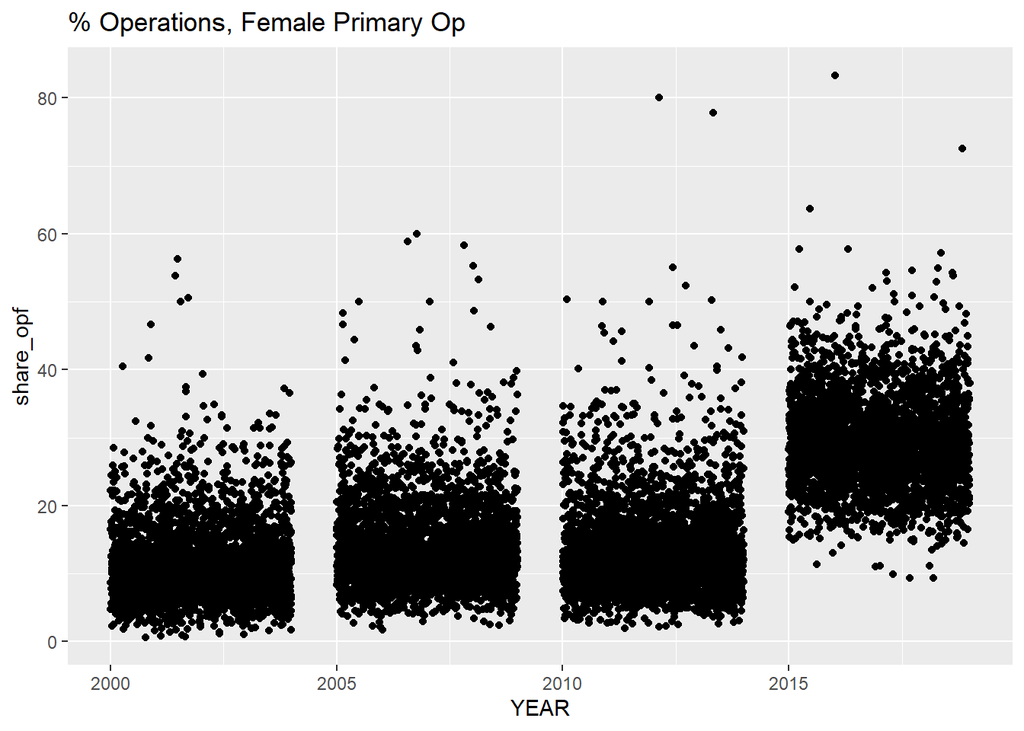

```r
ggplot(percf_p, aes(YEAR, share_opf)) + geom_jitter() + ggtitle("% Operations, Female Primary Op")
```

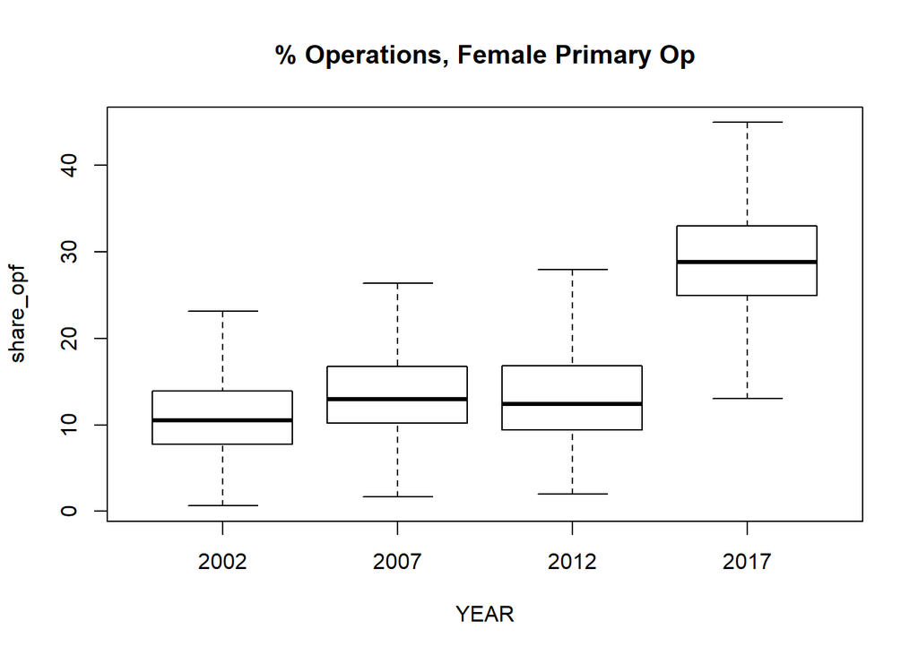

```r
boxplot(share_opf ~ YEAR, data = percf_p, main = "% Operations, Female Primary Op", outline=FALSE)
```

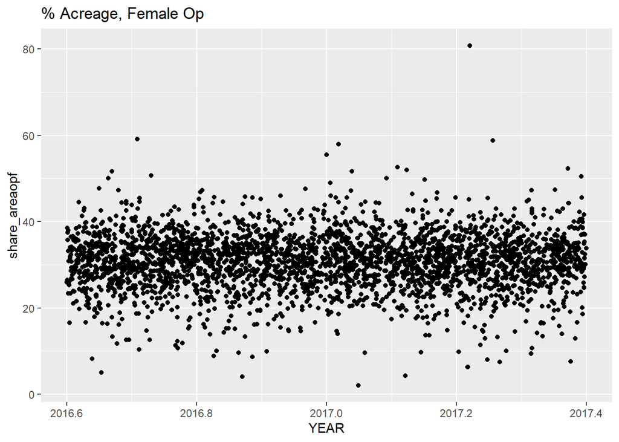

```r
# operators onlya share in 2017 (did not record males in previous years)
ggplot(percf_o, aes(YEAR, share_areaopf)) + geom_jitter() + ggtitle("% Acreage, Female Op")
```

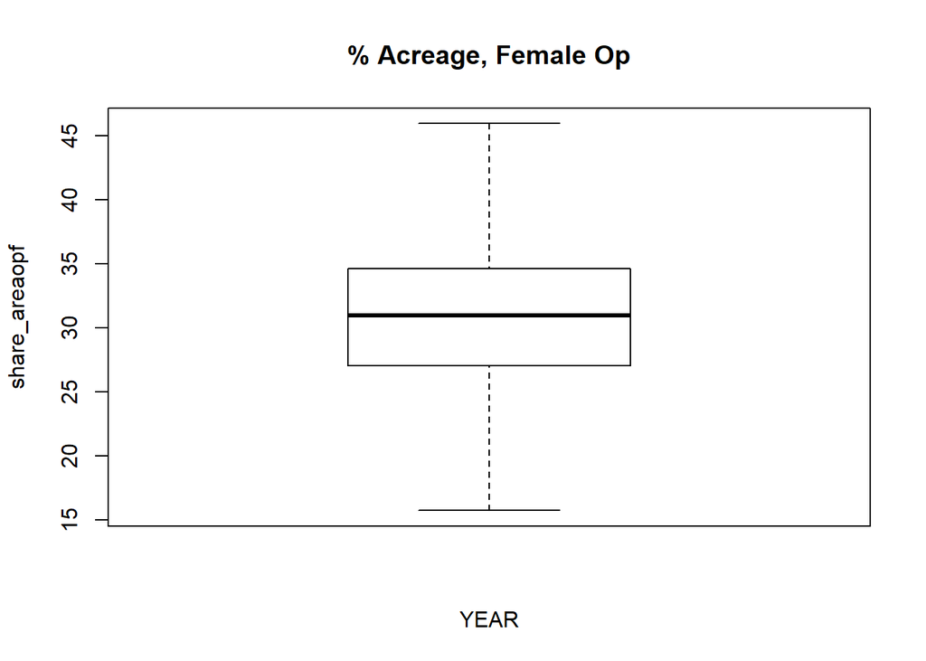

```r
boxplot(share_areaopf ~ YEAR, data = percf_o, main = "% Acreage, Female Op", outline=FALSE)
```

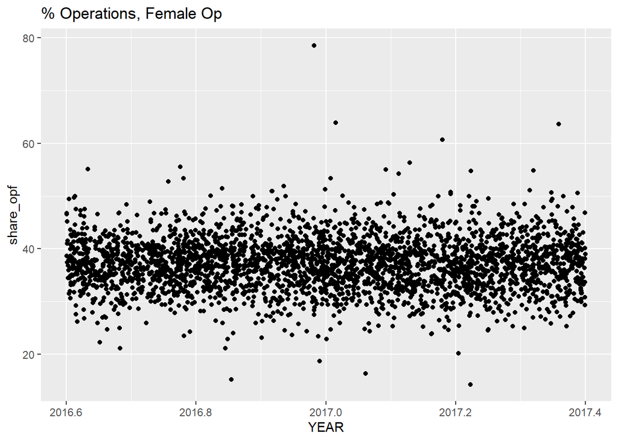

```r
ggplot(percf_o, aes(YEAR, share_opf)) + geom_jitter() + ggtitle("% Operations, Female Op")
```

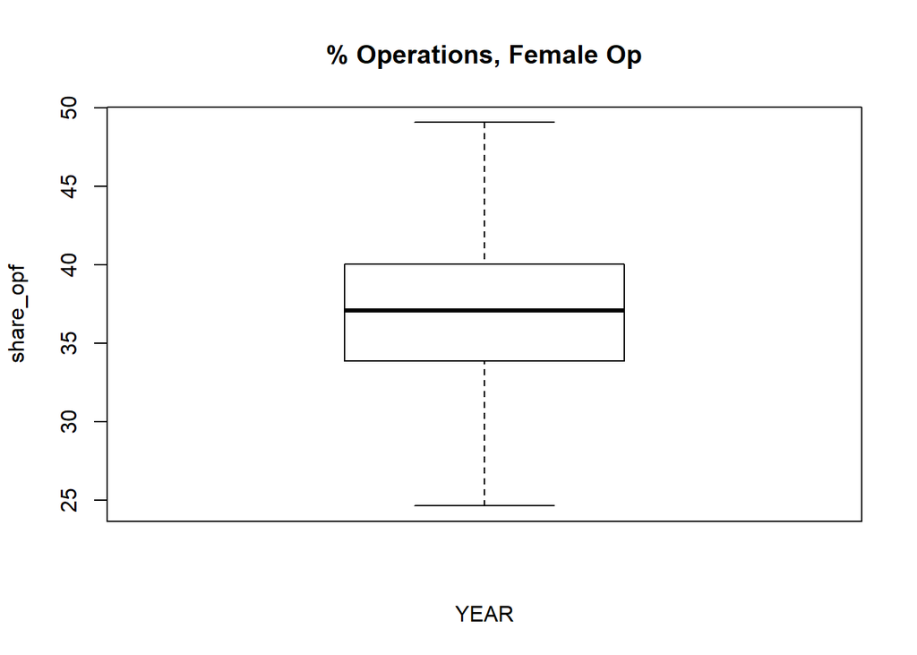

```r
boxplot(share_opf ~ YEAR, data = percf_o, main = "% Operations, Female Op", outline=FALSE)
```

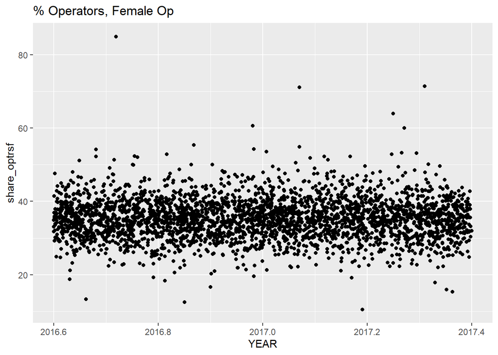

```r
ggplot(percf_o, aes(YEAR, share_optrsf)) + geom_jitter() + ggtitle("% Operators, Female Op")
```

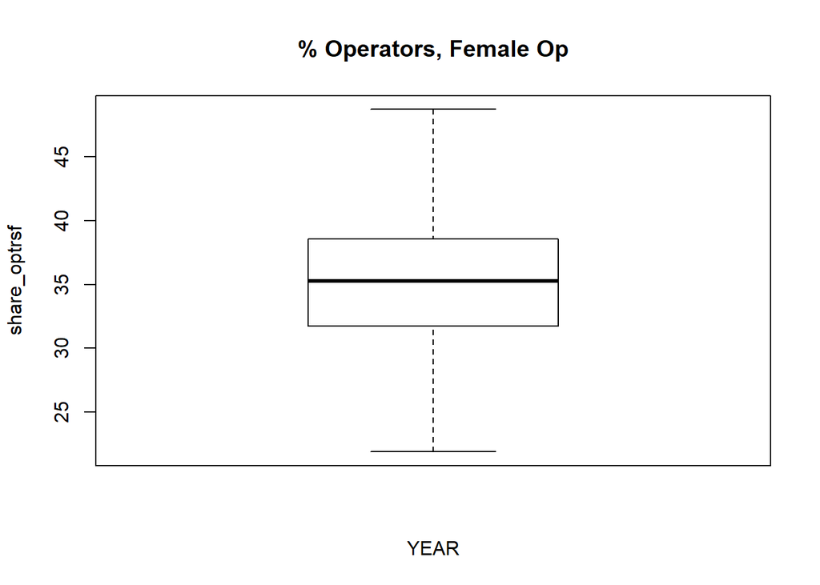

```r
boxplot(share_optrsf ~ YEAR, data = percf_o, main = "% Operators, Female Op", outline=FALSE)
```

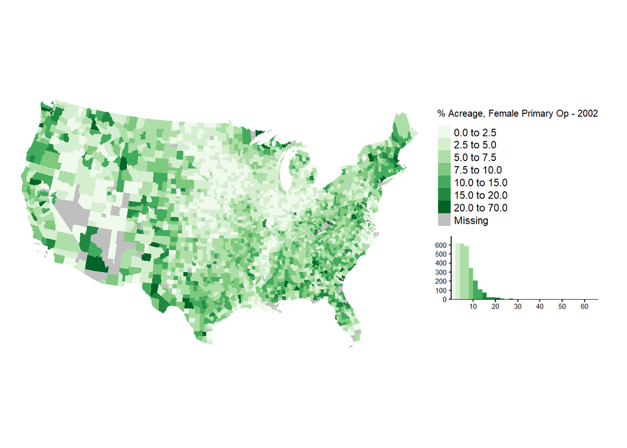

```r
# Maps
library(spdplyr)
library(tmap)
sp_percf <- sp::merge(cty, percf, by = "GEOID", duplicateGeoms = TRUE, all = TRUE)

build_sp_sex <- function(type, year, variable, colors, legend) {

  x <- sp_percf %>%
    filter(TYPE == type) %>%
    filter(YEAR == year)

  map <- tm_shape(cty) + tm_polygons(col="grey", border.col = "transparent") +
  tm_shape(x) +
    tm_polygons(col=variable, style = "quantile", n = 6, palette = colors, border.col = "transparent",
              legend.hist = TRUE, title = legend) +
    tm_legend(outside = TRUE, hist.width = 1.5) +
    tm_layout(frame= FALSE, legend.hist.size = 0.5)

  return(map)

}

build_sp_sex2 <- function(type, year, variable, breaks, colors, legend) {

  x <- sp_percf %>%
    filter(TYPE == type) %>%
    filter(YEAR == year)

  map <- tm_shape(cty) + tm_polygons(col="grey", border.col = "transparent") +
  tm_shape(x) +
    tm_polygons(col=variable, breaks = breaks, n = 6, palette = colors, border.col = "transparent",
              legend.hist = TRUE, title = legend) +
    tm_legend(outside = TRUE, hist.width = 1.5) +
    tm_layout(frame= FALSE, legend.hist.size = 0.5)

  return(map)

}

build_sp_sex2("OPERATORS, PRINCIPAL", 2002, "share_areaopf", c(0,2.5,5,7.5,10,15,20,70), "Greens", "% Acreage, Female Primary Op - 2002")
```

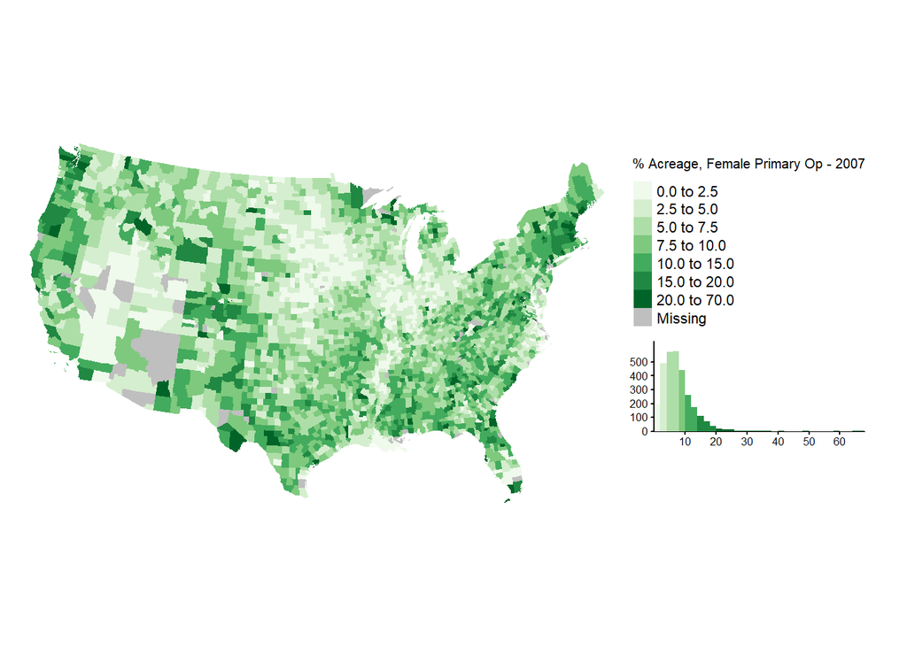

```r
build_sp_sex2("OPERATORS, PRINCIPAL", 2007, "share_areaopf", c(0,2.5,5,7.5,10,15,20,70), "Greens", "% Acreage, Female Primary Op - 2007")
```

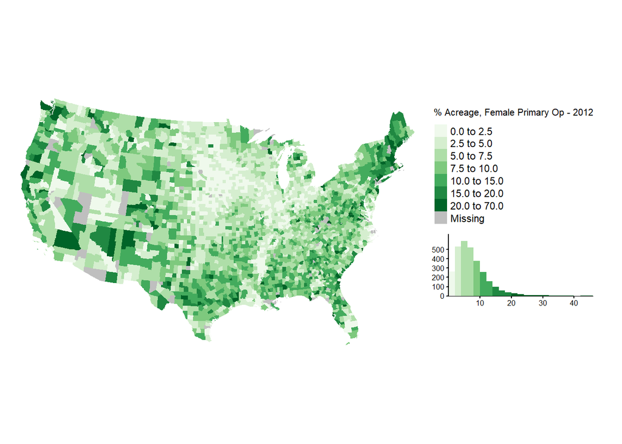

```r
build_sp_sex2("OPERATORS, PRINCIPAL", 2012, "share_areaopf", c(0,2.5,5,7.5,10,15,20,70), "Greens", "% Acreage, Female Primary Op - 2012")
```

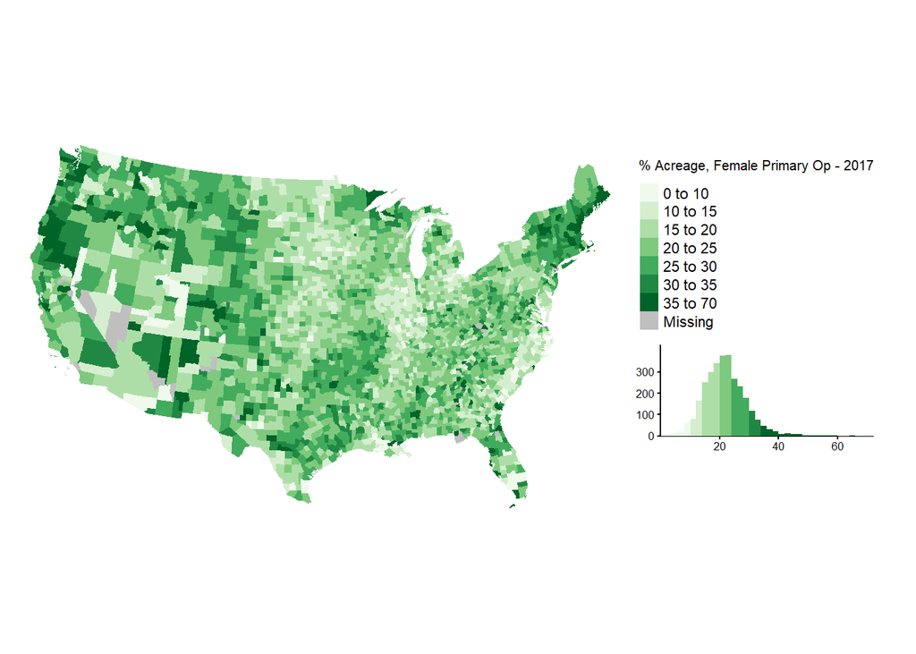

```r
build_sp_sex2("OPERATORS, PRINCIPAL", 2017, "share_areaopf", c(0,10,15,20,25,30,35,70), "Greens", "% Acreage, Female Primary Op - 2017")
```

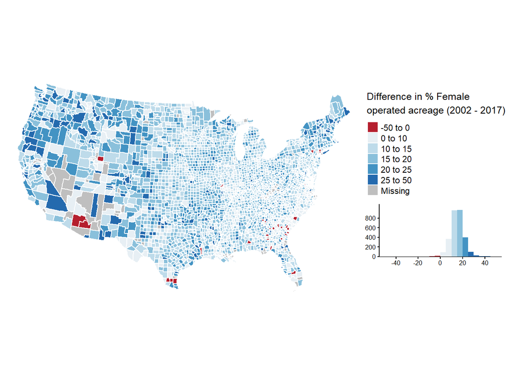

```r
# difference maps
x <- percf %>%
  filter(YEAR == 2002) %>%
  select(!YEAR)

x2 <- percf %>%
  filter(YEAR == 2017) %>%
  select(!YEAR)

y <- merge(x, x2, by = c("GEOID", "TYPE"))
ydiff <- y %>%
    mutate(diff_areaopf = share_areaopf.y - share_areaopf.x,
                          diff_opf = share_opf.y - share_opf.x) %>%
    select(GEOID, TYPE, diff_areaopf, diff_opf)

sp_diffsex <- sp::merge(cty, ydiff, by = "GEOID", duplicateGeoms = TRUE, all = TRUE)

library(RColorBrewer)
tm_shape(cty) + tm_polygons(col="grey", border.col = "transparent") +
  tm_shape(sp_diffsex) +
    tm_polygons(col= "diff_areaopf", breaks = c(-50,0,10,15,20,25,50), n = 6, palette = "RdBu", border.col = "white",
              legend.hist = TRUE, title = "Difference in % Female\noperated acreage (2002 - 2017)") +
    tm_legend(outside = TRUE, hist.width = 1.5) +
    tm_layout(frame= FALSE, legend.hist.size = 0.5)
```

So there's some cool stuff here.... female primary operators and operators in general have a HUGE bump in 2017 compared to the previous 3 COA years and almost ALL counties experience an increase in % female operatorship on agricultural lands between 2002 and 2017. Booya, ladies! Get it! Plus the data availability is REAL good.

# Race

```r
r <- do %>% filter(CLASS_DESC == "AMERICAN INDIAN OR ALASKA NATIVE" | CLASS_DESC == "BLACK OR AFRICAN AMERICAN" | CLASS_DESC == "MULTI-RACE" | CLASS_DESC == "WHITE" | CLASS_DESC == "HISPANIC" | CLASS_DESC == "ASIAN" | CLASS_DESC == "NATIVE HAWAIIAN OR OTHER PACIFIC ISLANDER") %>% filter(AGG_LEVEL_DESC == "COUNTY") %>% filter(DOMAIN_DESC == "TOTAL") %>% select(GEOID, YEAR, CLASS_DESC, COMMODITY_DESC, STATISTICCAT_DESC, UNIT_DESC, SHORT_DESC, VALUE)

levels(r$STATISTICCAT_DESC)[levels(r$STATISTICCAT_DESC)=="PRODUCERS"] <- "OPERATORS"
levels(r$COMMODITY_DESC)[levels(r$COMMODITY_DESC)=="PRODUCERS"] <- "OPERATORS"
levels(r$COMMODITY_DESC)[levels(r$COMMODITY_DESC)=="PRODUCERS, PRINCIPAL"] <- "OPERATORS, PRINCIPAL"

data_avail_race <- r %>%
  group_by(YEAR, SHORT_DESC) %>%
  summarise(count_NA = sum(is.na(VALUE)),
            n = sum(length(VALUE))) %>%
  mutate(perc = 1 - (count_NA/n)) %>% # availability determined by NA/n
  mutate(cty_rep = (n/3130)) %>% # percent of cty's represented in data
  mutate(t_m = (3130-n) + count_NA) %>% # total number of missing data points (including NA and non-existent data)
  mutate(t = 1 - (t_m/3130))
data_avail_race
```

```
## # A tibble: 143 x 8
## # Groups:   YEAR [4]
##     YEAR SHORT_DESC                     count_NA     n  perc cty_rep   t_m     t
##    <int> <fct>                             <int> <int> <dbl>   <dbl> <dbl> <dbl>
##  1  2002 OPERATORS, AMERICAN INDIAN OR~      879  2029 0.567   0.648  1980 0.367
##  2  2002 OPERATORS, AMERICAN INDIAN OR~        0  2029 1       0.648  1101 0.648
##  3  2002 OPERATORS, AMERICAN INDIAN OR~        0  2029 1       0.648  1101 0.648
##  4  2002 OPERATORS, ASIAN - ACRES OPER~      683  1096 0.377   0.350  2717 0.132
##  5  2002 OPERATORS, ASIAN - NUMBER OF ~        0  1096 1       0.350  2034 0.350
##  6  2002 OPERATORS, ASIAN - NUMBER OF ~        0  1096 1       0.350  2034 0.350
##  7  2002 OPERATORS, BLACK OR AFRICAN A~      420  1554 0.730   0.496  1996 0.362
##  8  2002 OPERATORS, BLACK OR AFRICAN A~        0  1554 1       0.496  1576 0.496
##  9  2002 OPERATORS, BLACK OR AFRICAN A~        0  1554 1       0.496  1576 0.496
## 10  2002 OPERATORS, HISPANIC - ACRES O~      549  2756 0.801   0.881   923 0.705
## # ... with 133 more rows
```

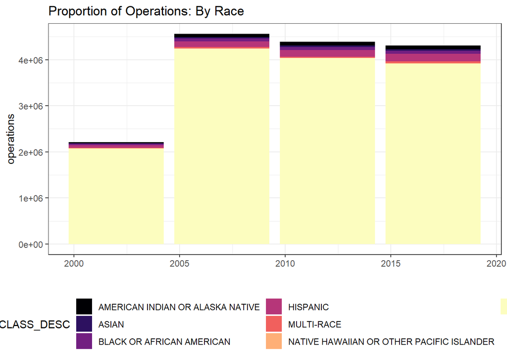

```r
rw <- r %>% select(GEOID, YEAR, CLASS_DESC, SHORT_DESC, COMMODITY_DESC, STATISTICCAT_DESC, VALUE) %>% filter(STATISTICCAT_DESC == "OPERATORS" | STATISTICCAT_DESC == "OPERATIONS" | STATISTICCAT_DESC == "AREA OPERATED") %>% filter(COMMODITY_DESC == "OPERATORS" | COMMODITY_DESC == "OPERATORS, PRINCIPAL") %>% filter(SHORT_DESC != "OPERATORS, HISPANIC, YEARS ON PRESENT OPERATION, GE 10 YEARS - NUMBER OF OPERATORS" & SHORT_DESC != "OPERATORS, HISPANIC, YEARS ON PRESENT OPERATION, 3 TO 4 YEARS - NUMBER OF OPERATORS" & SHORT_DESC != "OPERATORS, HISPANIC, YEARS ON PRESENT OPERATION, 5 TO 9 YEARS - NUMBER OF OPERATORS" & SHORT_DESC != "OPERATORS, HISPANIC, YEARS ON PRESENT OPERATION, LT 3 YEARS - NUMBER OF OPERATORS" & SHORT_DESC != "OPERATORS, HISPANIC, PRIMARY OCCUPATION, FARMING - NUMBER OF OPERATORS" & SHORT_DESC != "OPERATORS, HISPANIC, PRIMARY OCCUPATION, (EXCL FARMING) - NUMBER OF OPERATORS" & SHORT_DESC != "OPERATORS, HISPANIC, DAYS WORKED OFF OPERATION, 0 DAYS - NUMBER OF OPERATORS" & SHORT_DESC != "OPERATORS, HISPANIC, DAYS WORKED OFF OPERATION, GE 1 DAYS - NUMBER OF OPERATORS" & SHORT_DESC != "OPERATORS, HISPANIC - AREA OPERATED, MEASURED IN ACRES / OPERATION" & SHORT_DESC != "OPERATORS, HISPANIC - AGE, AVG, MEASURED IN YEARS") %>% select(!SHORT_DESC)

rw %>% filter(!is.na(VALUE)) %>% filter(STATISTICCAT_DESC == "OPERATIONS") %>%  group_by(YEAR, CLASS_DESC) %>% summarise(operations = sum(VALUE))  %>%
ggplot(.) +
    geom_bar(aes(fill=CLASS_DESC, y=operations, x=YEAR), position="stack", stat="identity") +
    scale_fill_viridis(discrete = T, option = "magma") +
    ggtitle("Proportion of Operations: By Race") +
    theme_bw() +
    xlab("") +
    theme(legend.position="bottom") + guides(fill = guide_legend(nrow = 3))
```

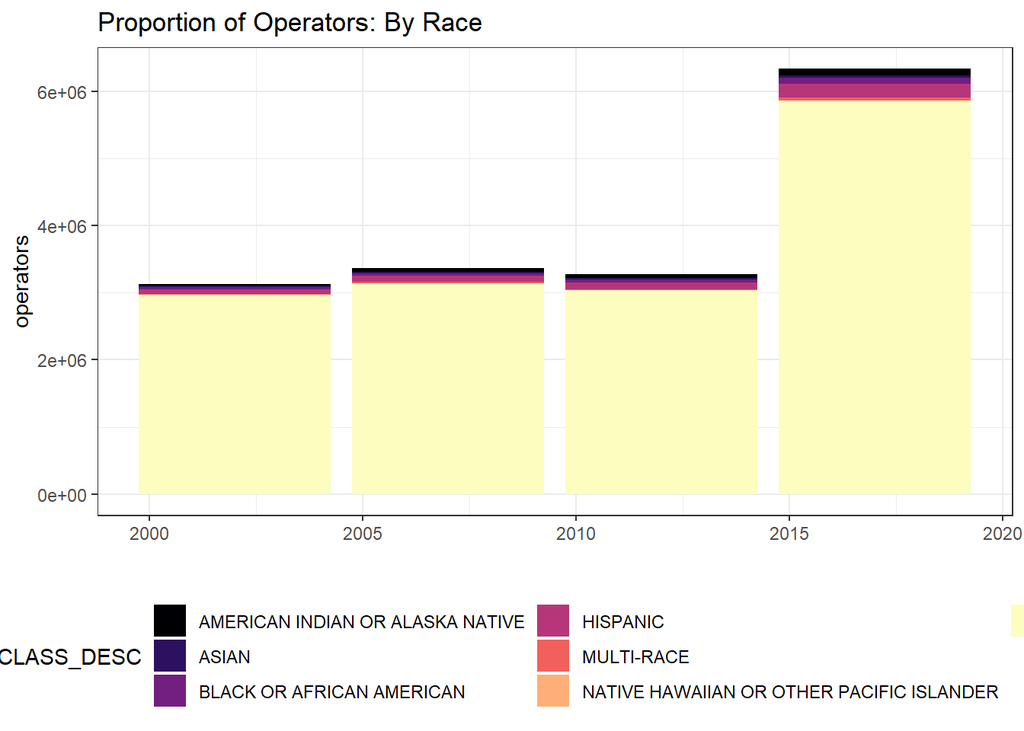

```r
rw %>% filter(!is.na(VALUE)) %>% filter(STATISTICCAT_DESC == "OPERATORS") %>%  group_by(YEAR, CLASS_DESC) %>% summarise(operators = sum(VALUE))  %>%
ggplot(.) +
    geom_bar(aes(fill=CLASS_DESC, y=operators, x=YEAR), position="stack", stat="identity") +
    scale_fill_viridis(discrete = T, option = "magma") +
    ggtitle("Proportion of Operators: By Race") +
    theme_bw() +
    xlab("") +
    theme(legend.position="bottom") + guides(fill = guide_legend(nrow = 3))
```